# Науменко, репликация

2024-02-26

```r
library(tidyverse)
library(pwr)
library(lme4)
library('lmerTest')
library(readxl)
library(simr)
library(knitr)
```

# Анализ мощности

#### Группа с однозначными примерами

```r
naum_data <- read_excel("C:/Users/allahverdov.vm/Desktop/work/naumenko_rep/original_exp/все данные.xls",
    sheet = "все данные")
naum_3group <- naum_data %>% filter(Группа == 3)
naum_3group$Тип_прайма <- naum_3group$`Верный / неверный прайм` %>% as.factor()
naum_3group_mn <- naum_3group %>%
                    group_by(`#`, Тип_прайма) %>%
                    mutate(Группа) %>%
                    summarise(Время_ср = mean(Время))
```

```
## argument.
```

```r
naum_3group_mn <- naum_3group_mn %>% ungroup()
#t.test paired
rstatix::t_test(naum_3group_mn, Время_ср ~ Тип_прайма, paired = TRUE, alternative = "two.sided")
```

```
## # A tibble: 1 × 8
##   .y.      group1 group2     n1    n2 statistic    df      p
## * <chr>    <chr>  <chr>   <int> <int>     <dbl> <dbl>  <dbl>
## 1 Время_ср верно  неверно    18    18     -2.22    17 0.0404
```

```r
#размер эффекта
rstatix::cohens_d(naum_3group_mn, Время_ср ~ Тип_прайма, paired = TRUE)
```

```
## # A tibble: 1 × 7
##   .y.      group1 group2  effsize    n1    n2 magnitude
## * <chr>    <chr>  <chr>     <dbl> <int> <int> <ord>
## 1 Время_ср верно  неверно  -0.523    18    18 moderate
```

```r
pwr::pwr.t.test(d = 0.5229, power = 0.8, sig.level = 0.04, type = "paired")
```

```
##
##      Paired t test power calculation
##
##               n = 32.82211
##               d = 0.5229
##       sig.level = 0.04
##           power = 0.8
##     alternative = two.sided
##
## NOTE: n is number of *pairs*
```

#### Группа с трёхзначными примерами

```r
naum_7group <- naum_data %>% filter(Группа == 7)
naum_7group$Тип_прайма <- naum_7group$`Верный / неверный прайм` %>% as.factor()
naum_7group$Тип_цели <- naum_7group$`Верный/ неверный целевой стимул` %>% as.factor()
naum_7group$Правильность <- naum_7group$`Правильно / неправильно` %>% as.factor()
naum_7group_mn <- naum_7group %>%
                    group_by(`#`, Тип_прайма) %>%
                    mutate(Группа) %>%
                    summarise(Время_ср = mean(Время))
```

```
## argument.
```

```r
naum_7group_mn <- naum_7group_mn %>% ungroup()
#t.test paired
rstatix::t_test(naum_7group_mn, Время_ср ~ Тип_прайма, paired = TRUE, alternative = "two.sided")
```

```
## # A tibble: 1 × 8
##   .y.      group1 group2     n1    n2 statistic    df     p
## * <chr>    <chr>  <chr>   <int> <int>     <dbl> <dbl> <dbl>
## 1 Время_ср верно  неверно    19    19    -0.657    18 0.519
```

```r
naum_7group_mn <- naum_7group %>%
                    group_by(`#`, Тип_прайма, Тип_цели) %>%
                    mutate(Группа) %>%
                    summarise(Время_ср = mean(Время))
naum_7group_mn <- naum_7group_mn %>% ungroup()
#t.test paired
rstatix::t_test(naum_7group_mn %>% filter(Тип_цели == "верно"), Время_ср ~ Тип_прайма, paired = TRUE, alternative = "two.sided")
```

```
## # A tibble: 1 × 8
##   .y.      group1 group2     n1    n2 statistic    df     p
## * <chr>    <chr>  <chr>   <int> <int>     <dbl> <dbl> <dbl>
## 1 Время_ср верно  неверно    19    19    -0.198    18 0.845
```

```r
rstatix::t_test(naum_7group_mn %>% filter(Тип_цели == "неверно"), Время_ср ~ Тип_прайма, paired = TRUE, alternative = "two.sided")
```

```
## # A tibble: 1 × 8
##   .y.      group1 group2     n1    n2 statistic    df     p
## * <chr>    <chr>  <chr>   <int> <int>     <dbl> <dbl> <dbl>
## 1 Время_ср верно  неверно    19    19     -1.07    18   0.3
```

```r
naum_7group$Правильность %>% table()
```

```
## .
##   0   1
## 565 575
```

```r
naum_7group$Тип_прайма <- (naum_7group$Тип_прайма == "верно") %>% as.numeric() + 1
naum_7group$Тип_цели <- (naum_7group$Тип_цели == "верно") %>% as.numeric() + 1
naum_7group$Правильность <- naum_7group$Правильность %>% as.numeric()
naum_7group_mn <- naum_7group %>%
                    group_by(`#`, Тип_прайма, Тип_цели, Правильность) %>%
                    mutate(Группа) %>%
                    summarise(Время_ср = mean(Время),
                              Наблюдений_в_условии = n())
#чекаем всё на анове
anova_model1 <- lm(Время_ср ~ Тип_прайма+Тип_цели+Правильность, naum_7group_mn)
car::Anova(anova_model1)
```

```
## Anova Table (Type II tests)
##
## Response: Время_ср
##                  Sum Sq  Df F value Pr(>F)
## Тип_прайма       803457   1  0.0773 0.7814
## Тип_цели          52196   1  0.0050 0.9436
## Правильность      37007   1  0.0036 0.9525
## Residuals    1497567629 144
```

```r
#с переменной группы
naum_7group_mn$Группа <- str_c(naum_7group_mn$Тип_прайма, naum_7group_mn$Тип_цели, naum_7group_mn$Правильность) %>% as.factor
anova_model1 <- lm(Время_ср ~ Группа, naum_7group_mn)


#размер эффекта
#rstatix::cohens_d(naum_7group_mn, Время_ср ~ Тип_прайма, paired = TRUE)
```

Ничего нет, ни каких значимостей.

# Загрукза данных

```r
base_data <- read_csv('data/naumenko_rep - responses.csv')
```

```
## ──────────────────────────────────────────────────────── Delimiter: "," chr
## (19): sender, sender_type, sender_id, response, response_action, ended_... dbl
## (8): id, group, is_online, counter, df_fixation_time, df_prime_time, a... num
## (1): duration dttm (1): timestamp
```

```r
# тип прайма
base_data$prime_type <- base_data$df_prime_correctness
base_data$rt <- base_data$duration
base_data$tg_type <- base_data$df_target_correctness

base_data$prime_type <- (base_data$prime_type == "верно") %>% as.numeric() + 1
base_data$prime_type <- base_data$prime_type %>% as.factor()
base_data$tg_type <- (base_data$tg_type == "верно") %>% as.numeric() + 1
base_data$tg_type <- base_data$tg_type %>% as.factor()
base_data$df_target <- base_data$df_target %>% as.factor()
base_data$prime_visible %>% table()
```

```
## .
##  no yes
##  70  10
```

```r
base_data$prime_example %>% unique()
```

```
##  [1] NA
##  [2] "Видела, что мелькали, но не могу указать"
##  [3] "нет"
##  [4] "-"
##  [5] "замечала их присутствие но не читала"
##  [6] "5*5=35 9*9=..."
##  [7] "не успевала понять"
##  [8] "замечала, но не осознавала"
##  [9] "Затрудняюсь ответить"
## [10] "4+7=45"
## [11] "9*9=72"
```

```r
base_data %>% str()
```

```
## spc_tbl_ [5,024 × 32] (S3: spec_tbl_df/tbl_df/tbl/data.frame)
##  $ id                   : num [1:5024] 1 1 1 1 1 1 1 1 1 1 ...
##  $ group                : num [1:5024] 1 NA NA NA NA NA NA NA NA NA ...
##  $ is_online            : num [1:5024] 1 1 1 1 1 1 1 1 1 1 ...
##  $ sender               : chr [1:5024] NA "Стимулы *код" "Стимулы *код" "Стимулы *код" ...
##  $ sender_type          : chr [1:5024] NA "canvas.Screen" "canvas.Screen" "canvas.Screen" ...
##  $ sender_id            : chr [1:5024] NA "3_0_3" "3_1_3" "3_2_3" ...
##  $ counter              : num [1:5024] NA 0 1 2 3 4 5 6 7 8 ...
##  $ response             : chr [1:5024] NA "верно" "неверно" "верно" ...
##  $ duration             : num [1:5024] NA 1270 713 279 573 ...
##  $ response_action      : chr [1:5024] NA "keydown(ArrowRight)" "keydown(ArrowLeft)" "keydown(ArrowRight)" ...
##  $ ended_on             : chr [1:5024] NA "response" "response" "response" ...
##  $ timestamp            : POSIXct[1:5024], format: NA "2024-01-16 14:56:39" ...
##  $ df_prime_awareness   : chr [1:5024] NA "неосознаваемый" "неосознаваемый" "неосознаваемый" ...
##  $ df_prime_difficulty  : chr [1:5024] NA "простой" "простой" "простой" ...
##  $ df_prime_correctness : chr [1:5024] NA "неверно" "неверно" "неверно" ...
##  $ df_target_difficulty : chr [1:5024] NA "простой" "простой" "простой" ...
##  $ df_target_correctness: chr [1:5024] NA "верно" "неверно" "верно" ...
##  $ df_fixation_time     : num [1:5024] NA 600 600 600 600 600 600 600 600 600 ...
##  $ df_prime_time        : num [1:5024] NA 60 60 60 60 60 60 60 60 60 ...
##  $ df_prime             : chr [1:5024] NA "4*6=28" "3*8=32" "9*2=16" ...
##  $ df_target            : Factor w/ 120 levels "134 * 878 = 117652",..: NA 94 75 21 45 73 8 74 110 63 ...
##  $ df_mask              : chr [1:5024] NA "ХХХХХХ" "ХХХХХХ" "ХХХХХХ" ...
##  $ age                  : num [1:5024] NA NA NA NA NA NA NA NA NA NA ...
##  $ sex                  : chr [1:5024] NA NA NA NA ...
##  $ prime_visible        : chr [1:5024] NA NA NA NA ...
##  $ prime_example        : chr [1:5024] NA NA NA NA ...
##  $ data                 : chr [1:5024] "[{\"df_prime_awareness\":\"неосознаваемый\",\"df_prime_difficulty\":\"простой\",\"df_prime_correctness\":\"неве"| __truncated__ NA NA NA ...
##  $ ...28                : num [1:5024] NA NA 61 0 20 0 NA NA NA NA ...
##  $ ...29                : chr [1:5024] NA NA "1 вариант" "2 вариант" ...
##  $ prime_type           : Factor w/ 2 levels "1","2": NA 1 1 1 1 2 2 1 2 1 ...
##  $ rt                   : num [1:5024] NA 1270 713 279 573 ...
##  $ tg_type              : Factor w/ 2 levels "1","2": NA 2 1 2 1 1 1 2 2 2 ...
##  - attr(*, "spec")=
##   .. cols(
##   ..   id = col_double(),
##   ..   group = col_double(),
##   ..   is_online = col_double(),
##   ..   sender = col_character(),
##   ..   sender_type = col_character(),
```

[output cut: 11 more lines]

```
##   ..   df_target_correctness = col_character(),
##   ..   df_fixation_time = col_double(),
##   ..   df_prime_time = col_double(),
##   ..   df_prime = col_character(),
##   ..   df_target = col_character(),
##   ..   df_mask = col_character(),
##   ..   age = col_double(),
##   ..   sex = col_character(),
##   ..   prime_visible = col_character(),
##   ..   prime_example = col_character(),
##   ..   data = col_character(),
##   ..   ...28 = col_double(),
##   ..   ...29 = col_character()
##   .. )
##  - attr(*, "problems")=<externalptr>
```

# Предобработка

## Выбросы

Выброс тех, кто приводил пример праймов, а также тех кто сильно выбивается по возрасту

```r
#data %>% filter(prime_example == "9*9=72") #59
#data %>% filter(prime_example == "5*5=35 9*9=...") #21
#data %>% filter(age == 67) #25
```

```r
base_data <- base_data %>% filter(id != 25 & id != 21 & id != 59)
base_data[base_data$id == 44, 'age'] <- 25
```

## Предобработка

```r
base_data %>%
  arrange(id) %>%
  group_by(id) %>%
  mutate(group = first(group), age = last(age), sex = last(sex), prime_visible = last(prime_visible[sender == "Проверка_на_бессознательность"]), prime_example = first(prime_example)) -> data
```

## Демография

```r
demographic <- data %>%
                  filter(is_online == 0 & group == 1) %>%
                  group_by(id, age, sex, is_online, prime_visible, group) %>%
                  summarise(mean_rt = mean(rt))
```

```
## 'prime_visible'. You can override using the `.groups` argument.
```

```r
demographic %>% summary()
```

```
##        id             age            sex              is_online
##  Min.   :19.00   Min.   :18.00   Length:40          Min.   :0
##  1st Qu.:30.75   1st Qu.:21.75   Class :character   1st Qu.:0
##  Median :40.50   Median :23.00   Mode  :character   Median :0
##  Mean   :40.38   Mean   :24.23                      Mean   :0
##  3rd Qu.:50.25   3rd Qu.:26.25                      3rd Qu.:0
##  Max.   :61.00   Max.   :35.00                      Max.   :0
##
##  prime_visible          group      mean_rt
##  Length:40          Min.   :1   Min.   : NA
##  Class :character   1st Qu.:1   1st Qu.: NA
##  Mode  :character   Median :1   Median : NA
##                     Mean   :1   Mean   :NaN
##                     3rd Qu.:1   3rd Qu.: NA
##                     Max.   :1   Max.   : NA
##                                 NA's   :40
```

```r
demographic$sex %>% table()
```

```
## .
##  f  m
## 29 11
```

## Чистка

```r
data$id %>% unique() %>% length()
```

```
## [1] 77
```

```r
data$id %>% unique() %>% length()
```

```
## [1] 77
```

```r
data <- data %>% filter(sender != is.na(sender))
data <- data %>% filter(sender != "Проверка_на_бессознательность")
data <- data %>% filter(sender != "Анкета")
data <- data %>% filter(group == 1)
data$is_online %>% table()
```

```
## .
##    0    1
## 2400 1080
```

# Группа 1

## Усреденние

data_mn_1 - усреднение по человеку и типу прайма data_mn_2 - усреднение по правильности не правильности targets - усреднение по целям

data_group_1_online - онлайн данные по 1 группе data_group_1_offline - офлайн данные по 1 группе

```r
data_mn_1 <- data %>%
  group_by(id, prime_type, is_online) %>%
  mutate(group) %>%
  summarise(mean_rt = mean(rt))
data_mn_2 <- data %>%
  group_by(id, prime_type, tg_type) %>%
  summarise(mean_rt = mean(rt))
targets <- data %>%
  group_by(counter, df_target, prime_type) %>%
  summarise(mean_rt = mean(rt))
data_mn_1 <- data_mn_1 %>% ungroup()

data_group_1_online <- data_mn_1 %>% filter(is_online == 1)
data_group_1_offline <- data_mn_1 %>% filter(is_online == 0)
```

## Сравнение средних между условиями офлайн***

```r
#распределение разницы между условий
subtraction <- filter(data_group_1_offline, prime_type == 1)$mean_rt - filter(data_group_1_offline, prime_type == 2)$mean_rt
subtraction %>% mean()
```

```
## [1] 116.0941
```

```r
subtraction %>% sd()
```

```
## [1] 252.4794
```

```r
#нормальность
shapiro.test(subtraction)
```

```
##
##  Shapiro-Wilk normality test
##
## data:  subtraction
## W = 0.96841, p-value = 0.3202
```

```r
#t.test paired
rstatix::t_test(data_group_1_offline, mean_rt ~ prime_type, paired = TRUE, alternative = "two.sided")
```

```
## # A tibble: 1 × 8
##   .y.     group1 group2    n1    n2 statistic    df       p
## * <chr>   <chr>  <chr>  <int> <int>     <dbl> <dbl>   <dbl>
## 1 mean_rt 1      2         40    40      2.91    39 0.00597
```

```r
#размер эффекта
rstatix::cohens_d(data_group_1_offline, mean_rt ~ prime_type, paired = TRUE)
```

```
## # A tibble: 1 × 7
##   .y.     group1 group2 effsize    n1    n2 magnitude
## * <chr>   <chr>  <chr>    <dbl> <int> <int> <ord>
## 1 mean_rt 1      2        0.460    40    40 small
```

```r
#негативный прайминг
filter(data_group_1_offline, prime_type == 1)$mean_rt %>% mean()
```

```
## [1] 1883.088
```

```r
#позитивный прайминг
filter(data_group_1_offline, prime_type == 2)$mean_rt %>% mean()
```

```
## [1] 1766.994
```

```r
#смешанная модель
mix_data <- data %>% filter(is_online == 0)

mix4 <- lmer(rt ~ 1 + (1|id), REML = FALSE, data = mix_data)
summary(mix4)
```

```
## Linear mixed model fit by maximum likelihood . t-tests use Satterthwaite's
##   method [lmerModLmerTest]
## Formula: rt ~ 1 + (1 | id)
##    Data: mix_data
##
##      AIC      BIC   logLik deviance df.resid
##  41042.9  41060.2 -20518.4  41036.9     2397
##
## Scaled residuals:
##     Min      1Q  Median      3Q     Max
## -2.2783 -0.4217 -0.1749  0.1641 11.2373
##
## Random effects:
##  Groups   Name        Variance Std.Dev.
##  id       (Intercept)  426033   652.7
##  Residual             1487318  1219.6
## Number of obs: 2400, groups:  id, 40
##
## Fixed effects:
##             Estimate Std. Error     df t value Pr(>|t|)
## (Intercept)   1825.0      106.2   40.0   17.19   <2e-16 ***
## ---
## Signif. codes:  0 '***' 0.001 '**' 0.01 '*' 0.05 '.' 0.1 ' ' 1
```

```r
mix5 <- lmer(rt ~ prime_type + (1|id), REML = FALSE, data = mix_data)
summary(mix5)
```

```
## Linear mixed model fit by maximum likelihood . t-tests use Satterthwaite's
##   method [lmerModLmerTest]
## Formula: rt ~ prime_type + (1 | id)
##    Data: mix_data
##
##      AIC      BIC   logLik deviance df.resid
##  41039.5  41062.6 -20515.7  41031.5     2396
##
## Scaled residuals:
##     Min      1Q  Median      3Q     Max
## -2.2335 -0.4314 -0.1735  0.1728 11.2027
##
## Random effects:
##  Groups   Name        Variance Std.Dev.
##  id       (Intercept)  426090   652.8
##  Residual             1483892  1218.2
## Number of obs: 2400, groups:  id, 40
##
## Fixed effects:
##             Estimate Std. Error      df t value Pr(>|t|)
## (Intercept)  1883.09     109.04   44.51  17.270   <2e-16 ***
## prime_type2  -116.09      49.73 2360.00  -2.334   0.0197 *
## ---
## Signif. codes:  0 '***' 0.001 '**' 0.01 '*' 0.05 '.' 0.1 ' ' 1
##
## Correlation of Fixed Effects:
##             (Intr)
## prime_type2 -0.228
```

```r
mix6 <- lmer(rt ~ prime_type + (1|id) + (1|df_target), REML = FALSE, data = mix_data)
summary(mix6)
```

```
## Linear mixed model fit by maximum likelihood . t-tests use Satterthwaite's
##   method [lmerModLmerTest]
## Formula: rt ~ prime_type + (1 | id) + (1 | df_target)
##    Data: mix_data
##
##      AIC      BIC   logLik deviance df.resid
##  40866.0  40894.9 -20428.0  40856.0     2395
##
## Scaled residuals:
##     Min      1Q  Median      3Q     Max
## -2.1379 -0.4399 -0.1268  0.1981 11.4309
##
## Random effects:
##  Groups    Name        Variance Std.Dev.
##  df_target (Intercept)  166426   408.0
##  id        (Intercept)  431123   656.6
##  Residual              1316690  1147.5
## Number of obs: 2400, groups:  df_target, 60; id, 40
##
## Fixed effects:
##             Estimate Std. Error      df t value Pr(>|t|)
## (Intercept)  1883.09     132.00   76.54  14.266   <2e-16 ***
## prime_type2  -116.09     115.28   59.42  -1.007    0.318
## ---
## Signif. codes:  0 '***' 0.001 '**' 0.01 '*' 0.05 '.' 0.1 ' ' 1
##
## Correlation of Fixed Effects:
##             (Intr)
## prime_type2 -0.437
```

```r
mix7 <- lmer(rt ~ prime_type + counter + (1|id), REML = FALSE, data = mix_data)
summary(mix7)
```

```
## Linear mixed model fit by maximum likelihood . t-tests use Satterthwaite's
##   method [lmerModLmerTest]
## Formula: rt ~ prime_type + counter + (1 | id)
##    Data: mix_data
##
##      AIC      BIC   logLik deviance df.resid
##  41027.8  41056.8 -20508.9  41017.8     2395
##
## Scaled residuals:
##     Min      1Q  Median      3Q     Max
## -2.1420 -0.4348 -0.1741  0.1485 11.1190
##
## Random effects:
##  Groups   Name        Variance Std.Dev.
##  id       (Intercept)  426232   652.9
##  Residual             1475361  1214.6
## Number of obs: 2400, groups:  id, 40
##
## Fixed effects:
##             Estimate Std. Error       df t value Pr(>|t|)
## (Intercept) 2024.239    115.522   56.050  17.523  < 2e-16 ***
## prime_type2  -80.537     50.513 2360.000  -1.594 0.110986
## counter       -5.387      1.458 2360.000  -3.694 0.000226 ***
## ---
## Signif. codes:  0 '***' 0.001 '**' 0.01 '*' 0.05 '.' 0.1 ' ' 1
##
## Correlation of Fixed Effects:
##             (Intr) prm_t2
## prime_type2 -0.148
## counter     -0.331 -0.191
```

```r
mix8 <- lmer(rt ~ prime_type + tg_type + counter + (1|id), REML = FALSE, data = mix_data)
summary(mix8)
```

```
## Linear mixed model fit by maximum likelihood . t-tests use Satterthwaite's
##   method [lmerModLmerTest]
## Formula: rt ~ prime_type + tg_type + counter + (1 | id)
##    Data: mix_data
##
##      AIC      BIC   logLik deviance df.resid
##  40991.2  41025.9 -20489.6  40979.2     2394
##
## Scaled residuals:
##     Min      1Q  Median      3Q     Max
## -2.0372 -0.4185 -0.1650  0.1630 11.3427
##
## Random effects:
##  Groups   Name        Variance Std.Dev.
##  id       (Intercept)  426632   653.2
##  Residual             1451378  1204.7
## Number of obs: 2400, groups:  id, 40
##
## Fixed effects:
##             Estimate Std. Error       df t value Pr(>|t|)
## (Intercept) 2172.736    117.801   60.586  18.444  < 2e-16 ***
## prime_type2  -81.823     50.101 2360.000  -1.633 0.102571
## tg_type2    -307.204     49.194 2360.000  -6.245 5.02e-10 ***
## counter       -5.193      1.447 2360.000  -3.589 0.000339 ***
## ---
## Signif. codes:  0 '***' 0.001 '**' 0.01 '*' 0.05 '.' 0.1 ' ' 1
##
## Correlation of Fixed Effects:
##             (Intr) prm_t2 tg_ty2
## prime_type2 -0.144
## tg_type2    -0.202  0.004
## counter     -0.317 -0.191 -0.022
```

```r
anova(mix4, mix5) %>% print() #AIC падает - модель лучше
```

```
## Data: mix_data
## Models:
## mix4: rt ~ 1 + (1 | id)
## mix5: rt ~ prime_type + (1 | id)
##      npar   AIC   BIC logLik deviance  Chisq Df Pr(>Chisq)
## mix4    3 41043 41060 -20518    41037
## mix5    4 41039 41063 -20516    41031 5.4434  1    0.01964 *
## ---
## Signif. codes:  0 '***' 0.001 '**' 0.01 '*' 0.05 '.' 0.1 ' ' 1
```

```r
anova(mix5, mix6) %>% print() #AIC падает - модель лучше
```

```
## Data: mix_data
## Models:
## mix5: rt ~ prime_type + (1 | id)
## mix6: rt ~ prime_type + (1 | id) + (1 | df_target)
##      npar   AIC   BIC logLik deviance  Chisq Df Pr(>Chisq)
## mix5    4 41039 41063 -20516    41031
## mix6    5 40866 40895 -20428    40856 175.45  1  < 2.2e-16 ***
## ---
## Signif. codes:  0 '***' 0.001 '**' 0.01 '*' 0.05 '.' 0.1 ' ' 1
```

```r
anova(mix7, mix8) %>% print() #AIC падает - модель лучше
```

```
## Data: mix_data
## Models:
## mix7: rt ~ prime_type + counter + (1 | id)
## mix8: rt ~ prime_type + tg_type + counter + (1 | id)
##      npar   AIC   BIC logLik deviance  Chisq Df Pr(>Chisq)
## mix7    5 41028 41057 -20509    41018
## mix8    6 40991 41026 -20490    40979 38.678  1  4.999e-10 ***
## ---
## Signif. codes:  0 '***' 0.001 '**' 0.01 '*' 0.05 '.' 0.1 ' ' 1
```

## Сравнение средних между условиями онлайн

```r
#распределение разницы между условий
subtraction <- filter(data_group_1_online, prime_type == 1)$mean_rt - filter(data_group_1_online, prime_type == 2)$mean_rt
subtraction %>% mean()
```

```
## [1] 439.0478
```

```r
subtraction %>% sd()
```

```
## [1] 801.4959
```

```r
#нормальность
shapiro.test(subtraction)
```

```
##
##  Shapiro-Wilk normality test
##
## data:  subtraction
## W = 0.68759, p-value = 5.749e-05
```

```r
#t.test paired
rstatix::wilcox_test(data_group_1_online, mean_rt ~ prime_type, paired = TRUE)
```

```
## # A tibble: 1 × 7
##   .y.     group1 group2    n1    n2 statistic        p
## * <chr>   <chr>  <chr>  <int> <int>     <dbl>    <dbl>
## 1 mean_rt 1      2         18    18       158 0.000671
```

```r
#негативный прайминг
filter(data_group_1_online, prime_type == 1)$mean_rt %>% mean()
```

```
## [1] 2805.645
```

```r
#позитивный прайминг
filter(data_group_1_online, prime_type == 2)$mean_rt %>% mean()
```

```
## [1] 2366.598
```

## Графики

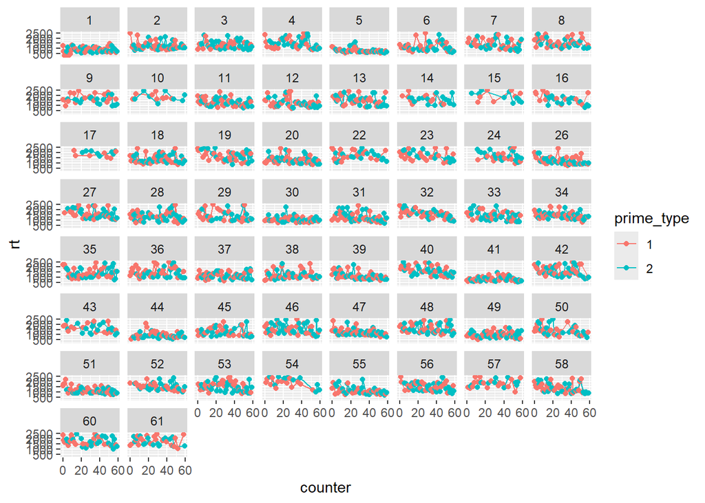

```r
#графики точек по каждому испытуемому
data %>%
  filter(rt < 2500)%>%
  ggplot(aes(counter, rt, color = prime_type))+
  geom_line()+
  geom_point()+
  facet_wrap(~id)
```

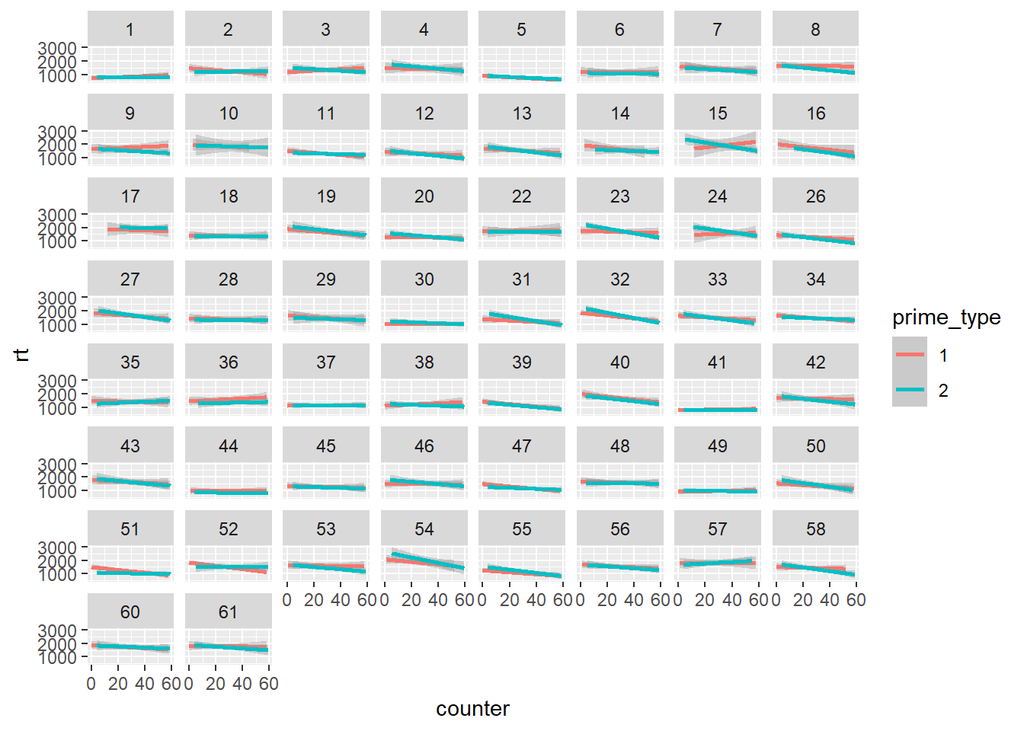

```r
#графики линий тенденций по каждому испытуемому
data %>%
  filter(rt < 2500)%>%
  ggplot(aes(counter, rt, color = prime_type))+
  geom_smooth(method = "lm")+
  facet_wrap(~id)
```

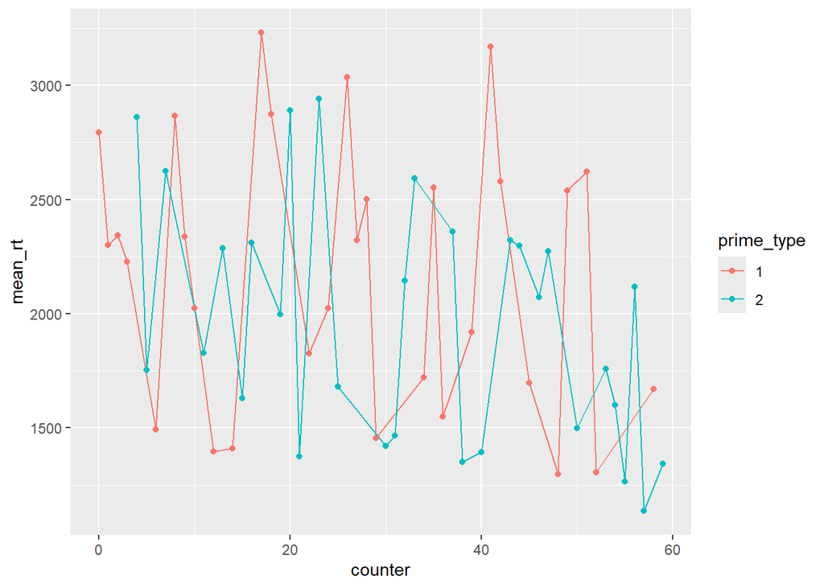

```r
#графики линий тенденций по каждому испытуемому
targets %>%
  ggplot(aes(counter, mean_rt, color = prime_type))+
  geom_line()+
  geom_point()
```

## Верные / Неверные ответы онлайн

```r
data_mn_5 <- data %>%
  group_by(id, prime_type, tg_type, is_online) %>%
  mutate(group) %>%
  summarise(mean_rt = mean(rt))
data_mn_5
```

```
## # A tibble: 232 × 5
## # Groups:   id, prime_type, tg_type [232]
##       id prime_type tg_type is_online mean_rt
##    <dbl> <fct>      <fct>       <dbl>   <dbl>
##  1     1 1          1               1    921.
##  2     1 1          2               1    792.
##  3     1 2          1               1    914.
##  4     1 2          2               1    744.
##  5     2 1          1               1   2009.
##  6     2 1          2               1   1355.
##  7     2 2          1               1   1739.
##  8     2 2          2               1   1456.
##  9     3 1          1               1   1950.
## 10     3 1          2               1   1602.
## # ℹ 222 more rows
```

```r
data_mn_5 <- data_mn_5 %>% ungroup()
# Разделение датасета
data_group_5_online <- data_mn_5 %>% filter(is_online == 1)
data_group_5_offline <- data_mn_5 %>% filter(is_online == 0)
```

#### Сравнение двух условий (правильность прайма, правильность цели) онлайн

```r
#негативные целевые
rstatix::wilcox_test(data_group_5_online %>% filter(tg_type == 1),
                     mean_rt ~ prime_type,
                     paired = TRUE)
```

```
## # A tibble: 1 × 7
##   .y.     group1 group2    n1    n2 statistic      p
## * <chr>   <chr>  <chr>  <int> <int>     <dbl>  <dbl>
## 1 mean_rt 1      2         18    18       127 0.0737
```

```r
#позитивные целевые
rstatix::wilcox_test(data_group_5_online %>% filter(tg_type == 2),
                     mean_rt ~ prime_type,
                     paired = TRUE)
```

```
## # A tibble: 1 × 7
##   .y.     group1 group2    n1    n2 statistic      p
## * <chr>   <chr>  <chr>  <int> <int>     <dbl>  <dbl>
## 1 mean_rt 1      2         18    18       140 0.0159
```

```r
#таблица средних
data_group_5_online %>%
  group_by(prime_type, tg_type) %>%
  summarise(rt = mean(mean_rt))
```

```
## # A tibble: 4 × 3
## # Groups:   prime_type [2]
##   prime_type tg_type    rt
##   <fct>      <fct>   <dbl>
## 1 1          1       3066.
## 2 1          2       2545.
## 3 2          1       2620.
## 4 2          2       2114.
```

#### Сравнение двух условий (правильность прайма, правильность цели) офлайн

```r
#негативные целевые
rstatix::wilcox_test(data_group_5_offline %>% filter(tg_type == 1),
                     mean_rt ~ prime_type,
                     paired = TRUE)
```

```
## # A tibble: 1 × 7
##   .y.     group1 group2    n1    n2 statistic       p
## * <chr>   <chr>  <chr>  <int> <int>     <dbl>   <dbl>
## 1 mean_rt 1      2         40    40       606 0.00758
```

```r
#позитивные целевые
rstatix::wilcox_test(data_group_5_offline %>% filter(tg_type == 2),
                     mean_rt ~ prime_type,
                     paired = TRUE)
```

```
## # A tibble: 1 × 7
##   .y.     group1 group2    n1    n2 statistic       p
## * <chr>   <chr>  <chr>  <int> <int>     <dbl>   <dbl>
## 1 mean_rt 1      2         40    40       638 0.00168
```

```r
#таблица средних
data_group_5_offline %>%
  group_by(prime_type, tg_type) %>%
  summarise(rt = mean(mean_rt))
```

```
## # A tibble: 4 × 3
## # Groups:   prime_type [2]
##   prime_type tg_type    rt
##   <fct>      <fct>   <dbl>
## 1 1          1       2033.
## 2 1          2       1734.
## 3 2          1       1928.
## 4 2          2       1606.
```

#### Зависимость время реакция от типа целевых стимулов (онлайн)

```r
rstatix::wilcox_test(data_group_5_online, mean_rt ~ tg_type, paired = TRUE)
```

```
## # A tibble: 1 × 7
##   .y.     group1 group2    n1    n2 statistic         p
## * <chr>   <chr>  <chr>  <int> <int>     <dbl>     <dbl>
## 1 mean_rt 1      2         36    36       570 0.0000847
```

```r
#среднее онлайн тг = неправильный
filter(data_group_5_online, tg_type == 1)$mean_rt %>% mean()
```

```
## [1] 2842.931
```

```r
#среднее онлайн тг = правильные
filter(data_group_5_online, tg_type == 2)$mean_rt %>% mean()
```

```
## [1] 2329.311
```

#### Зависимость время реакция от типа целевых стимулов (офлайн)

```r
# Зависимость время реакция от типа целевых стимулов (офлайн)
rstatix::wilcox_test(data_group_5_offline, mean_rt ~ tg_type, paired = TRUE)
```

```
## # A tibble: 1 × 7
##   .y.     group1 group2    n1    n2 statistic        p
## * <chr>   <chr>  <chr>  <int> <int>     <dbl>    <dbl>
## 1 mean_rt 1      2         80    80      2920 4.58e-10
```

```r
#среднее офлайн тг = неправильный
filter(data_group_5_offline, tg_type == 1)$mean_rt %>% mean()
```

```
## [1] 1980.547
```

```r
#среднее офлайн тг = правильные
filter(data_group_5_offline, tg_type == 2)$mean_rt %>% mean()
```

```
## [1] 1669.535
```

## Графики

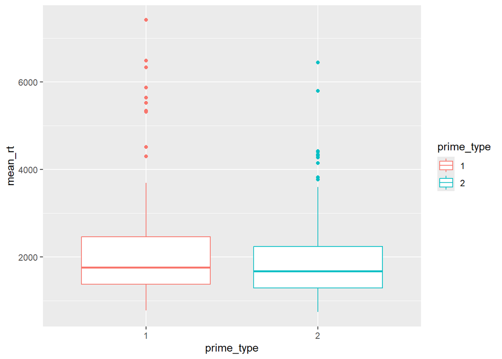

```r
# boxplot по усреднённым
data_mn_5 %>%
  ggplot(aes(prime_type, mean_rt, color = prime_type))+
  geom_boxplot()
```

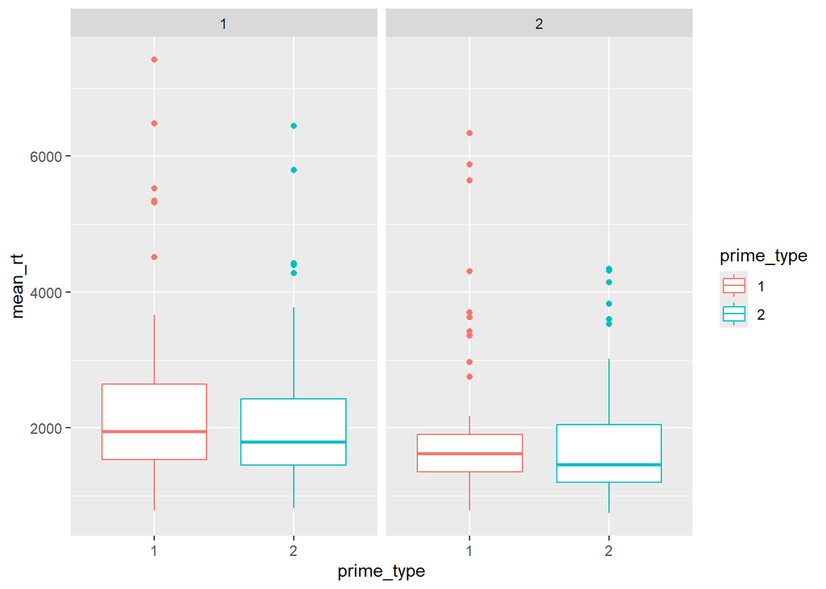

```r
# boxplot по усреднённым с типом цели
data_mn_5 %>%
  ggplot(aes(prime_type, mean_rt, color = prime_type))+
  geom_boxplot()+
  facet_wrap(~tg_type)
```

## Разделение на правильные и неправильные задачи. Для коротких примеров офлайн

```r
mix_data <- data %>% filter(is_online == 0 & group == 1)
mix_data$df_target <- mix_data$df_target %>% as.factor()
mix_data$response <- mix_data$response %>% as.factor()
mix_data$is_visible <- (mix_data$prime_visible == 'yes') %>% as.numeric() %>%  as.factor()


mix_model_3 <- lmer(rt ~ prime_type + tg_type + (1|id), REML = FALSE, data = mix_data)
summary(mix_model_3)
```

```
## Linear mixed model fit by maximum likelihood . t-tests use Satterthwaite's
##   method [lmerModLmerTest]
## Formula: rt ~ prime_type + tg_type + (1 | id)
##    Data: mix_data
##
##      AIC      BIC   logLik deviance df.resid
##  41002.0  41030.9 -20496.0  40992.0     2395
##
## Scaled residuals:
##     Min      1Q  Median      3Q     Max
## -2.1251 -0.4372 -0.1641  0.1769 11.4259
##
## Random effects:
##  Groups   Name        Variance Std.Dev.
##  id       (Intercept)  426500   653.1
##  Residual             1459300  1208.0
## Number of obs: 2400, groups:  id, 40
##
## Fixed effects:
##             Estimate Std. Error      df t value Pr(>|t|)
## (Intercept)  2038.59     111.74   49.09  18.244  < 2e-16 ***
## prime_type2  -116.09      49.32 2360.00  -2.354   0.0187 *
## tg_type2     -311.01      49.32 2360.00  -6.306  3.4e-10 ***
## ---
## Signif. codes:  0 '***' 0.001 '**' 0.01 '*' 0.05 '.' 0.1 ' ' 1
##
## Correlation of Fixed Effects:
##             (Intr) prm_t2
## prime_type2 -0.221
## tg_type2    -0.221  0.000
```

```r
mix_model_4 <- lmer(rt ~ prime_type + tg_type + counter + (1|id), REML = FALSE, data = mix_data)
mix_model_4.1 <- lmer(rt ~ tg_type + counter + (1|id), REML = FALSE, data = mix_data)

summary(mix_model_4)
```

```
## Linear mixed model fit by maximum likelihood . t-tests use Satterthwaite's
##   method [lmerModLmerTest]
## Formula: rt ~ prime_type + tg_type + counter + (1 | id)
##    Data: mix_data
##
##      AIC      BIC   logLik deviance df.resid
##  40991.2  41025.9 -20489.6  40979.2     2394
##
## Scaled residuals:
##     Min      1Q  Median      3Q     Max
## -2.0372 -0.4185 -0.1650  0.1630 11.3427
##
## Random effects:
##  Groups   Name        Variance Std.Dev.
##  id       (Intercept)  426632   653.2
##  Residual             1451378  1204.7
## Number of obs: 2400, groups:  id, 40
##
## Fixed effects:
##             Estimate Std. Error       df t value Pr(>|t|)
## (Intercept) 2172.736    117.801   60.586  18.444  < 2e-16 ***
## prime_type2  -81.823     50.101 2360.000  -1.633 0.102571
## tg_type2    -307.204     49.194 2360.000  -6.245 5.02e-10 ***
## counter       -5.193      1.447 2360.000  -3.589 0.000339 ***
## ---
## Signif. codes:  0 '***' 0.001 '**' 0.01 '*' 0.05 '.' 0.1 ' ' 1
##
## Correlation of Fixed Effects:
##             (Intr) prm_t2 tg_ty2
## prime_type2 -0.144
## tg_type2    -0.202  0.004
## counter     -0.317 -0.191 -0.022
```

```r
summary(mix_model_4.1)
```

```
## Linear mixed model fit by maximum likelihood . t-tests use Satterthwaite's
##   method [lmerModLmerTest]
## Formula: rt ~ tg_type + counter + (1 | id)
##    Data: mix_data
##
##      AIC      BIC   logLik deviance df.resid
##  40991.8  41020.8 -20490.9  40981.8     2395
##
## Scaled residuals:
##     Min      1Q  Median      3Q     Max
## -2.0605 -0.4251 -0.1631  0.1559 11.3590
##
## Random effects:
##  Groups   Name        Variance Std.Dev.
##  id       (Intercept)  426605   653.1
##  Residual             1453019  1205.4
## Number of obs: 2400, groups:  id, 40
##
## Fixed effects:
##             Estimate Std. Error       df t value Pr(>|t|)
## (Intercept) 2144.945    116.576   58.117  18.399  < 2e-16 ***
## tg_type2    -306.874     49.222 2360.000  -6.235 5.35e-10 ***
## counter       -5.643      1.421 2360.000  -3.971 7.38e-05 ***
## ---
## Signif. codes:  0 '***' 0.001 '**' 0.01 '*' 0.05 '.' 0.1 ' ' 1
##
## Correlation of Fixed Effects:
##          (Intr) tg_ty2
## tg_type2 -0.203
## counter  -0.355 -0.021
```

```r
anova(mix_model_3, mix_model_4)
```

```
## Data: mix_data
## Models:
## mix_model_3: rt ~ prime_type + tg_type + (1 | id)
## mix_model_4: rt ~ prime_type + tg_type + counter + (1 | id)
##             npar   AIC   BIC logLik deviance  Chisq Df Pr(>Chisq)
## mix_model_3    5 41002 41031 -20496    40992
## mix_model_4    6 40991 41026 -20490    40979 12.845  1  0.0003383 ***
## ---
## Signif. codes:  0 '***' 0.001 '**' 0.01 '*' 0.05 '.' 0.1 ' ' 1
```

```r
anova(mix_model_4, mix_model_4.1)
```

```
## Data: mix_data
## Models:
## mix_model_4.1: rt ~ tg_type + counter + (1 | id)
## mix_model_4: rt ~ prime_type + tg_type + counter + (1 | id)
##               npar   AIC   BIC logLik deviance  Chisq Df Pr(>Chisq)
## mix_model_4.1    5 40992 41021 -20491    40982
## mix_model_4      6 40991 41026 -20490    40979 2.6657  1     0.1025
```

```r
mix_model_5 <- lmer(rt ~ tg_type + (1|id) + (1|df_target), REML = FALSE, data = mix_data)
summary(mix_model_5)
```

```
## Linear mixed model fit by maximum likelihood . t-tests use Satterthwaite's
##   method [lmerModLmerTest]
## Formula: rt ~ tg_type + (1 | id) + (1 | df_target)
##    Data: mix_data
##
##      AIC      BIC   logLik deviance df.resid
##  40859.4  40888.3 -20424.7  40849.4     2395
##
## Scaled residuals:
##     Min      1Q  Median      3Q     Max
## -2.1364 -0.4447 -0.1283  0.2036 11.4761
##
## Random effects:
##  Groups    Name        Variance Std.Dev.
##  df_target (Intercept)  145404   381.3
##  id        (Intercept)  430873   656.4
##  Residual              1316691  1147.5
## Number of obs: 2400, groups:  df_target, 60; id, 40
##
## Fixed effects:
##             Estimate Std. Error      df t value Pr(>|t|)
## (Intercept)  1980.55     129.29   73.31  15.319  < 2e-16 ***
## tg_type2     -311.01     109.03   59.38  -2.852  0.00596 **
## ---
## Signif. codes:  0 '***' 0.001 '**' 0.01 '*' 0.05 '.' 0.1 ' ' 1
##
## Correlation of Fixed Effects:
##          (Intr)
## tg_type2 -0.422
```

```r
anova(mix_model_3, mix_model_5)
```

```
## Data: mix_data
## Models:
## mix_model_3: rt ~ prime_type + tg_type + (1 | id)
## mix_model_5: rt ~ tg_type + (1 | id) + (1 | df_target)
##             npar   AIC   BIC logLik deviance  Chisq Df Pr(>Chisq)
## mix_model_3    5 41002 41031 -20496    40992
## mix_model_5    5 40859 40888 -20425    40849 142.63  0
```

```r
anova(mix_model_4, mix_model_5)
```

```
## Data: mix_data
## Models:
## mix_model_5: rt ~ tg_type + (1 | id) + (1 | df_target)
## mix_model_4: rt ~ prime_type + tg_type + counter + (1 | id)
##             npar   AIC   BIC logLik deviance Chisq Df Pr(>Chisq)
## mix_model_5    5 40859 40888 -20425    40849
## mix_model_4    6 40991 41026 -20490    40979     0  1          1
```

```r
mix_model_6 <- lmer(rt ~ tg_type + counter + (1|id) + (1|df_target), REML = FALSE, data = mix_data)
summary(mix_model_6)
```

```
## Linear mixed model fit by maximum likelihood . t-tests use Satterthwaite's
##   method [lmerModLmerTest]
## Formula: rt ~ tg_type + counter + (1 | id) + (1 | df_target)
##    Data: mix_data
##
##      AIC      BIC   logLik deviance df.resid
##  40858.1  40892.8 -20423.0  40846.1     2394
##
## Scaled residuals:
##     Min      1Q  Median      3Q     Max
## -2.1165 -0.4440 -0.1293  0.2037 11.4552
##
## Random effects:
##  Groups    Name        Variance Std.Dev.
##  df_target (Intercept)  135758   368.5
##  id        (Intercept)  430761   656.3
##  Residual              1316691  1147.5
## Number of obs: 2400, groups:  df_target, 60; id, 40
##
## Fixed effects:
##             Estimate Std. Error       df t value Pr(>|t|)
## (Intercept) 2144.945    156.048   93.616  13.745  < 2e-16 ***
## tg_type2    -306.874    106.066   59.370  -2.893  0.00532 **
## counter       -5.643      3.062   59.370  -1.843  0.07036 .
## ---
## Signif. codes:  0 '***' 0.001 '**' 0.01 '*' 0.05 '.' 0.1 ' ' 1
##
## Correlation of Fixed Effects:
##          (Intr) tg_ty2
## tg_type2 -0.328
## counter  -0.572 -0.021
```

```r
anova(mix_model_5, mix_model_6)
```

```
## Data: mix_data
## Models:
## mix_model_5: rt ~ tg_type + (1 | id) + (1 | df_target)
## mix_model_6: rt ~ tg_type + counter + (1 | id) + (1 | df_target)
##             npar   AIC   BIC logLik deviance  Chisq Df Pr(>Chisq)
## mix_model_5    5 40859 40888 -20425    40849
## mix_model_6    6 40858 40893 -20423    40846 3.3021  1    0.06919 .
## ---
## Signif. codes:  0 '***' 0.001 '**' 0.01 '*' 0.05 '.' 0.1 ' ' 1
```

В той же модели tg_type 2 значимый предиктор. Если не брать смешанный фактор, то прайм значимый, если брать то уже не значимый. Нужен рандом, чтобы понять обусловлено ли влияние прайма эффектом последовательности.

anova(mix_model_3, mix_model_4) - модель, где есть counter значимо лучше

anova(mix_model_4, mix_model_5) - нет значимой разницы, соответственно лучше та модель, которая короче

anova(mix_model_5, mix_model_6) - близка к значимым различием, значит эффект научения может присутствовать

Но, одна из лучших моделей для офлайн данных - **rt ~ tg_type + (1|id) + (1|df_target), REML = FALSE**

**Тобишь результаты говорят о том, что tg_type (правильность целевой задачи), влияет на скорость ответа. Люди отвечают примерно на 300мс быстрее, если целевая задача с правильным решением. И с каждой задачей люди всё быстрее научаются её решать, примерно на 5 мс ↓ ↓ ↓ ↓ ↓**

```r
summary(mix_model_6)
```

```
## Linear mixed model fit by maximum likelihood . t-tests use Satterthwaite's
##   method [lmerModLmerTest]
## Formula: rt ~ tg_type + counter + (1 | id) + (1 | df_target)
##    Data: mix_data
##
##      AIC      BIC   logLik deviance df.resid
##  40858.1  40892.8 -20423.0  40846.1     2394
##
## Scaled residuals:
##     Min      1Q  Median      3Q     Max
## -2.1165 -0.4440 -0.1293  0.2037 11.4552
##
## Random effects:
##  Groups    Name        Variance Std.Dev.
##  df_target (Intercept)  135758   368.5
##  id        (Intercept)  430761   656.3
##  Residual              1316691  1147.5
## Number of obs: 2400, groups:  df_target, 60; id, 40
##
## Fixed effects:
##             Estimate Std. Error       df t value Pr(>|t|)
## (Intercept) 2144.945    156.048   93.616  13.745  < 2e-16 ***
## tg_type2    -306.874    106.066   59.370  -2.893  0.00532 **
## counter       -5.643      3.062   59.370  -1.843  0.07036 .
## ---
## Signif. codes:  0 '***' 0.001 '**' 0.01 '*' 0.05 '.' 0.1 ' ' 1
##
## Correlation of Fixed Effects:
##          (Intr) tg_ty2
## tg_type2 -0.328
## counter  -0.572 -0.021
```

## Разделение на правильные и неправильные задачи. Для коротких примеров офлайн + онлайн

```r
mix_data <- data %>% filter(group == 1)
mix_data$df_target <- mix_data$df_target %>% as.factor()
mix_data$response <- mix_data$response %>% as.factor()
mix_data$is_visible <- (mix_data$prime_visible == 'yes') %>% as.numeric() %>%  as.factor()


mix_model_3 <- lmer(rt ~ prime_type + tg_type + (1|id), REML = FALSE, data = mix_data)
summary(mix_model_3)
```

```
## Linear mixed model fit by maximum likelihood . t-tests use Satterthwaite's
##   method [lmerModLmerTest]
## Formula: rt ~ prime_type + tg_type + (1 | id)
##    Data: mix_data
##
##      AIC      BIC   logLik deviance df.resid
##  61813.9  61844.7 -30901.9  61803.9     3475
##
## Scaled residuals:
##     Min      1Q  Median      3Q     Max
## -2.4356 -0.3628 -0.1335  0.1390 13.5747
##
## Random effects:
##  Groups   Name        Variance Std.Dev.
##  id       (Intercept) 1138015  1067
##  Residual             2865720  1693
## Number of obs: 3480, groups:  id, 58
##
## Fixed effects:
##             Estimate Std. Error      df t value Pr(>|t|)
## (Intercept)  2356.34     148.63   67.71  15.854  < 2e-16 ***
## prime_type2  -216.32      57.39 3422.00  -3.769 0.000167 ***
## tg_type2     -373.89      57.39 3422.00  -6.515 8.36e-11 ***
## ---
## Signif. codes:  0 '***' 0.001 '**' 0.01 '*' 0.05 '.' 0.1 ' ' 1
##
## Correlation of Fixed Effects:
##             (Intr) prm_t2
## prime_type2 -0.193
## tg_type2    -0.193  0.000
```

```r
mix_model_4 <- lmer(rt ~ prime_type + tg_type + counter + (1|id), REML = FALSE, data = mix_data)
mix_model_4.1 <- lmer(rt ~ tg_type + counter + (1|id), REML = FALSE, data = mix_data)

summary(mix_model_4)
```

```
## Linear mixed model fit by maximum likelihood . t-tests use Satterthwaite's
##   method [lmerModLmerTest]
## Formula: rt ~ prime_type + tg_type + counter + (1 | id)
##    Data: mix_data
##
##      AIC      BIC   logLik deviance df.resid
##  61785.3  61822.3 -30886.7  61773.3     3474
##
## Scaled residuals:
##     Min      1Q  Median      3Q     Max
## -2.5734 -0.3633 -0.1334  0.1368 13.5321
##
## Random effects:
##  Groups   Name        Variance Std.Dev.
##  id       (Intercept) 1138440  1067
##  Residual             2840240  1685
## Number of obs: 3480, groups:  id, 58
##
## Fixed effects:
##             Estimate Std. Error       df t value Pr(>|t|)
## (Intercept) 2596.928    154.797   79.636  16.776  < 2e-16 ***
## prime_type2 -154.856     58.204 3422.000  -2.661  0.00784 **
## tg_type2    -367.061     57.150 3422.000  -6.423 1.52e-10 ***
## counter       -9.313      1.681 3422.000  -5.541 3.24e-08 ***
## ---
## Signif. codes:  0 '***' 0.001 '**' 0.01 '*' 0.05 '.' 0.1 ' ' 1
##
## Correlation of Fixed Effects:
##             (Intr) prm_t2 tg_ty2
## prime_type2 -0.128
## tg_type2    -0.178  0.004
## counter     -0.281 -0.191 -0.022
```

```r
anova(mix_model_3, mix_model_4)
```

```
## Data: mix_data
## Models:
## mix_model_3: rt ~ prime_type + tg_type + (1 | id)
## mix_model_4: rt ~ prime_type + tg_type + counter + (1 | id)
##             npar   AIC   BIC logLik deviance  Chisq Df Pr(>Chisq)
## mix_model_3    5 61814 61845 -30902    61804
## mix_model_4    6 61785 61822 -30887    61773 30.563  1  3.232e-08 ***
## ---
## Signif. codes:  0 '***' 0.001 '**' 0.01 '*' 0.05 '.' 0.1 ' ' 1
```

```r
anova(mix_model_4, mix_model_4.1)
```

```
## Data: mix_data
## Models:
## mix_model_4.1: rt ~ tg_type + counter + (1 | id)
## mix_model_4: rt ~ prime_type + tg_type + counter + (1 | id)
##               npar   AIC   BIC logLik deviance  Chisq Df Pr(>Chisq)
## mix_model_4.1    5 61790 61821 -30890    61780
## mix_model_4      6 61785 61822 -30887    61773 7.0713  1   0.007833 **
## ---
## Signif. codes:  0 '***' 0.001 '**' 0.01 '*' 0.05 '.' 0.1 ' ' 1
```

```r
mix_model_5 <- lmer(rt ~ prime_type + tg_type + counter + (1|id) + (1|df_target), REML = FALSE, data = mix_data)
mix_model_5.1 <- lmer(rt ~ tg_type + counter + (1|id) + (1|df_target), REML = FALSE, data = mix_data)
summary(mix_model_5)
```

```
## Linear mixed model fit by maximum likelihood . t-tests use Satterthwaite's
##   method [lmerModLmerTest]
## Formula: rt ~ prime_type + tg_type + counter + (1 | id) + (1 | df_target)
##    Data: mix_data
##
##      AIC      BIC   logLik deviance df.resid
##  61637.4  61680.5 -30811.7  61623.4     3473
##
## Scaled residuals:
##     Min      1Q  Median      3Q     Max
## -2.5500 -0.3916 -0.1080  0.1749 13.6718
##
## Random effects:
##  Groups    Name        Variance Std.Dev.
##  df_target (Intercept)  198918   446
##  id        (Intercept) 1144624  1070
##  Residual              2640637  1625
## Number of obs: 3480, groups:  df_target, 60; id, 58
##
## Fixed effects:
##             Estimate Std. Error       df t value Pr(>|t|)
## (Intercept) 2596.928    203.393  112.793  12.768  < 2e-16 ***
## prime_type2 -154.856    130.041   59.313  -1.191  0.23847
## tg_type2    -367.061    127.687   59.313  -2.875  0.00561 **
## counter       -9.313      3.755   59.313  -2.480  0.01600 *
## ---
## Signif. codes:  0 '***' 0.001 '**' 0.01 '*' 0.05 '.' 0.1 ' ' 1
##
## Correlation of Fixed Effects:
##             (Intr) prm_t2 tg_ty2
## prime_type2 -0.217
## tg_type2    -0.303  0.004
## counter     -0.477 -0.191 -0.022
```

```r
summary(mix_model_5.1)
```

```
## Linear mixed model fit by maximum likelihood . t-tests use Satterthwaite's
##   method [lmerModLmerTest]
## Formula: rt ~ tg_type + counter + (1 | id) + (1 | df_target)
##    Data: mix_data
##
##      AIC      BIC   logLik deviance df.resid
##  61636.8  61673.8 -30812.4  61624.8     3474
##
## Scaled residuals:
##     Min      1Q  Median      3Q     Max
## -2.5425 -0.3923 -0.1064  0.1741 13.6765
##
## Random effects:
##  Groups    Name        Variance Std.Dev.
##  df_target (Intercept)  204762   452.5
##  id        (Intercept) 1144692  1069.9
##  Residual              2640637  1625.0
## Number of obs: 3480, groups:  df_target, 60; id, 58
##
## Fixed effects:
##             Estimate Std. Error      df t value Pr(>|t|)
## (Intercept)  2544.33     199.72  112.63  12.739  < 2e-16 ***
## tg_type2     -366.44     129.20   59.32  -2.836  0.00624 **
## counter       -10.16       3.73   59.32  -2.725  0.00844 **
## ---
## Signif. codes:  0 '***' 0.001 '**' 0.01 '*' 0.05 '.' 0.1 ' ' 1
##
## Correlation of Fixed Effects:
##          (Intr) tg_ty2
## tg_type2 -0.312
## counter  -0.544 -0.021
```

```r
anova(mix_model_4, mix_model_5)
```

```
## Data: mix_data
## Models:
## mix_model_4: rt ~ prime_type + tg_type + counter + (1 | id)
## mix_model_5: rt ~ prime_type + tg_type + counter + (1 | id) + (1 | df_target)
##             npar   AIC   BIC logLik deviance  Chisq Df Pr(>Chisq)
## mix_model_4    6 61785 61822 -30887    61773
## mix_model_5    7 61637 61681 -30812    61623 149.91  1  < 2.2e-16 ***
## ---
## Signif. codes:  0 '***' 0.001 '**' 0.01 '*' 0.05 '.' 0.1 ' ' 1
```

```r
anova(mix_model_5, mix_model_5.1)
```

```
## Data: mix_data
## Models:
## mix_model_5.1: rt ~ tg_type + counter + (1 | id) + (1 | df_target)
## mix_model_5: rt ~ prime_type + tg_type + counter + (1 | id) + (1 | df_target)
##               npar   AIC   BIC logLik deviance  Chisq Df Pr(>Chisq)
## mix_model_5.1    6 61637 61674 -30812    61625
## mix_model_5      7 61637 61681 -30812    61623 1.4014  1     0.2365
```

```r
mix_model_6 <- lmer(rt ~ tg_type + counter + (1|id) + (1|df_target) +(1|is_online), REML = FALSE, data = mix_data)
summary(mix_model_6)
```

```
## Linear mixed model fit by maximum likelihood . t-tests use Satterthwaite's
##   method [lmerModLmerTest]
## Formula: rt ~ tg_type + counter + (1 | id) + (1 | df_target) + (1 | is_online)
##    Data: mix_data
##
##      AIC      BIC   logLik deviance df.resid
##  61636.9  61679.9 -30811.4  61622.9     3473
##
## Scaled residuals:
##     Min      1Q  Median      3Q     Max
## -2.5452 -0.3911 -0.1055  0.1746 13.6739
##
## Random effects:
##  Groups    Name        Variance Std.Dev.
##  df_target (Intercept)  205266   453.1
##  id        (Intercept) 1056216  1027.7
##  is_online (Intercept)  101939   319.3
##  Residual              2640621  1625.0
## Number of obs: 3480, groups:  df_target, 60; id, 58; is_online, 2
##
## Fixed effects:
##             Estimate Std. Error       df t value Pr(>|t|)
## (Intercept) 2644.939    302.649    3.008   8.739  0.00312 **
## tg_type2    -366.436    129.333   59.107  -2.833  0.00629 **
## counter      -10.165      3.734   59.107  -2.722  0.00851 **
## ---
## Signif. codes:  0 '***' 0.001 '**' 0.01 '*' 0.05 '.' 0.1 ' ' 1
##
## Correlation of Fixed Effects:
##          (Intr) tg_ty2
## tg_type2 -0.206
## counter  -0.359 -0.021
```

```r
anova(mix_model_5.1, mix_model_6)
```

```
## Data: mix_data
## Models:
## mix_model_5.1: rt ~ tg_type + counter + (1 | id) + (1 | df_target)
## mix_model_6: rt ~ tg_type + counter + (1 | id) + (1 | df_target) + (1 | is_online)
##               npar   AIC   BIC logLik deviance  Chisq Df Pr(>Chisq)
## mix_model_5.1    6 61637 61674 -30812    61625
## mix_model_6      7 61637 61680 -30811    61623 1.9666  1     0.1608
```

**rt ~ prime_type + tg_type + counter + (1|id)** - даёт хорошую значимость всех предикторов **anova(mix_model_4, mix_model_4.1)** - модель rt ~ prime_type + tg_type + counter + (1|id), REML = FALSE лучше

rt ~ prime_type + tg_type + (1|id) + (1|df_target), REML = FALSE - если делать смешанный фактор 1|df_target - значимость с типа прайма уходит.

anova(mix_model_4, mix_model_5) - значит, эта модель лучше чем, та **anova(mix_model_5, mix_model_5.1)** - значит, тип прайма не нужен и **rt ~ tg_type + counter + (1|id) + (1|df_target), REML = FALSE** уже достаточно хорошая модель

anova(mix_model_5.1, mix_model_6) - значимо не отличаются, соотвественно смешанный предиктор (1|is_online) ничего не даёт (то бишь нет разницы онлайн или не онлайн).

**По сути сейчас явно видно, что влияет tg_type (т.е. правильность целевой задачи). По всей видимости есть эффект научения связанный с количеством проб. - 366.44, означает, что когда задача правильная, человек ускоряется примерно на 360мс, также с каждой задачей, человек ускоряется примерно на 10мс. ↓ ↓ ↓ ↓ ↓ ↓**

```r
summary(mix_model_5.1)
```

```
## Linear mixed model fit by maximum likelihood . t-tests use Satterthwaite's
##   method [lmerModLmerTest]
## Formula: rt ~ tg_type + counter + (1 | id) + (1 | df_target)
##    Data: mix_data
##
##      AIC      BIC   logLik deviance df.resid
##  61636.8  61673.8 -30812.4  61624.8     3474
##
## Scaled residuals:
##     Min      1Q  Median      3Q     Max
## -2.5425 -0.3923 -0.1064  0.1741 13.6765
##
## Random effects:
##  Groups    Name        Variance Std.Dev.
##  df_target (Intercept)  204762   452.5
##  id        (Intercept) 1144692  1069.9
##  Residual              2640637  1625.0
## Number of obs: 3480, groups:  df_target, 60; id, 58
##
## Fixed effects:
##             Estimate Std. Error      df t value Pr(>|t|)
## (Intercept)  2544.33     199.72  112.63  12.739  < 2e-16 ***
## tg_type2     -366.44     129.20   59.32  -2.836  0.00624 **
## counter       -10.16       3.73   59.32  -2.725  0.00844 **
## ---
## Signif. codes:  0 '***' 0.001 '**' 0.01 '*' 0.05 '.' 0.1 ' ' 1
##
## Correlation of Fixed Effects:
##          (Intr) tg_ty2
## tg_type2 -0.312
## counter  -0.544 -0.021
```

```r
data %>%
  group_by(tg_type, prime_type) %>%
  summarise(mean_rt = mean(rt))
```

```
## # A tibble: 4 × 3
## # Groups:   tg_type [2]
##   tg_type prime_type mean_rt
##   <fct>   <fct>        <dbl>
## 1 1       1            2353.
## 2 1       2            2143.
## 3 2       1            1985.
## 4 2       2            1763.
```

Правильные целевые задачи быстрее.